### Introduction

The dataset originally consisted of 64000+ samples with 517 independent variables. The independent variables are a combination of demographic information and important social and policy related questions. [The detailed information of the pre and post questionnaire, response types and sampling techniques are available here](https://dataverse.harvard.edu/dataset.xhtml?persistentId=doi%3A10.7910/DVN/GDF6Z0). For the purpose of this competition I have selected a subset of the dataset. The following conditions were used to filter records.  
1) Individuals registered to vote [VoteReg==“Yes”]  
2) Individuals who took the post election survey [tookPost==“Yes”]  
3) Individuals who voted for either Hillary Clinton (Democratic candidate) or Donald Trump (Republican candidate)

Rest of the individuals would be used as an unseen test set.

I have used 5 demographic and 12 policy related independent variables to build my model. I have built 2 models  
1) A simple random forest ensemble learner.  
2) A gradient boosted decision trees

There is room for improvement with increasing the number of independent variables and using other complex learners.

#### Variables

The model consists of 17 independent variable and 1 dependent variable

#### Dependent variable

1. **VotedFor** - Voter’s true preference

#### Libraries used

1. **hot.deck** - For probability based imputation of missing values in records
2. **ranger** - A fast implementation of a random forest learner with provision for inclusion sample weights, samples with higher weights have higher sampling frequency
3. **GBM** - Gradient boosted decision trees with provision for sample weights
4. **mlR** - For parameter tuning, accuracy metrics and evaluating performance of model on randomly sampled test sets
5. **ggplot2** - For plots
6. **caret** - For calibration and confusion matrix

#### Initial analysis

```
               Levels Categorical Missing
commonweight    26810       FALSE       0
gender              2        TRUE       0
edloan              6        TRUE       0
race                8        TRUE       0
state              51        TRUE       0
economyyear         6        TRUE      45
economynext         7        TRUE      63
govrating           6        TRUE      17
grantlegstatus      2        TRUE       0
deportation         2        TRUE       0
cleanair            3        TRUE      33
defensecut          4        TRUE    1002
raisetax            4        TRUE     975
guncontrol          3        TRUE     241
medicare            3        TRUE     167
obamacare           3        TRUE      66
minwage             3        TRUE      10
employmentstat      9        TRUE       0
vote2016            2        TRUE       0
```

#### Missing value imputation

```r
#The imputed file is saved as train.Rdata

#dropping factor order

df[,2:ncol(df)]=data.frame(sapply(df[,2:ncol(df)],
                                  function(x)(factor(x,ordered = FALSE))))

#Hot deck imputation, saving the first imputed set as the train set
df=data.frame(hot.deck(df,m=2,method = "p.draw")$data[[1]])

df.init=data.frame(Levels = sapply(df,function(x)(length(unique(x)))),
                   Categorical = sapply(df,is.factor),
                   Missing = sapply(df,function(x)(sum(is.na(x)))))
df.init
```

```
               Levels Categorical Missing
commonweight    26810       FALSE       0
gender              2        TRUE       0
edloan              6        TRUE       0
race                8        TRUE       0
state              51        TRUE       0
economyyear         5        TRUE       0
economynext         6        TRUE       0
govrating           5        TRUE       0
grantlegstatus      2        TRUE       0
deportation         2        TRUE       0
cleanair            2        TRUE       0
defensecut          3        TRUE       0
raisetax            3        TRUE       0
guncontrol          2        TRUE       0
medicare            2        TRUE       0
obamacare           2        TRUE       0
minwage             2        TRUE       0
employmentstat      9        TRUE       0
vote2016            2        TRUE       0
```

```r
#File is available under the data folder, you can directly use this dataset for training
save(df,file="train.RData")
```

We do not need any data preprocessing as our data is categorical with a limited number of levels for each explanatory variable.

#### Cross validation

```r
set.seed(1000)

#MlR Cross validation (I have cross-validated using a single iteration in this report, I have alreay fine tuned this model)

param = makeParamSet(
makeDiscreteParam("num.trees", values = c(1000)),
makeDiscreteParam("min.node.size", values = c(60)),
makeDiscreteParam("mtry",values=c(4)))


task=makeClassifTask(id = deparse(substitute(df)), df[,2:19],"vote2016",
weights = df$commonweight, blocking = NULL, positive = NA_character_,
fixup.data = "warn", check.data = TRUE)

ctrl = makeTuneControlGrid()
rdesc = makeResampleDesc("CV", iters = 3L)


classif.ranger=makeLearner("classif.ranger",predict.type = "prob")

tuneParams(classif.ranger, task = task, resampling = rdesc,
par.set = param, control = ctrl,measures = list(auc,f1,logloss))
```

```
Tune result:
Op. pars: num.trees=1000; min.node.size=60; mtry=4
auc.test.mean=0.965,f1.test.mean=0.889,logloss.test.mean=0.243
```

```r
#best tuned
classif.ranger=makeLearner("classif.ranger",predict.type = "prob"
,num.trees=500
,min.node.size=40
,mtry=4)


n = getTaskSize(task)
train.set = sample(n, size = 2*n/3)
test.set = setdiff(1:n, train.set)

model = mlr::train(classif.ranger, task, subset = train.set,weights = df[train.set,1])
pred1 = predict(model, task = task,subset = test.set)
```

#### ROC analysis for random Forest

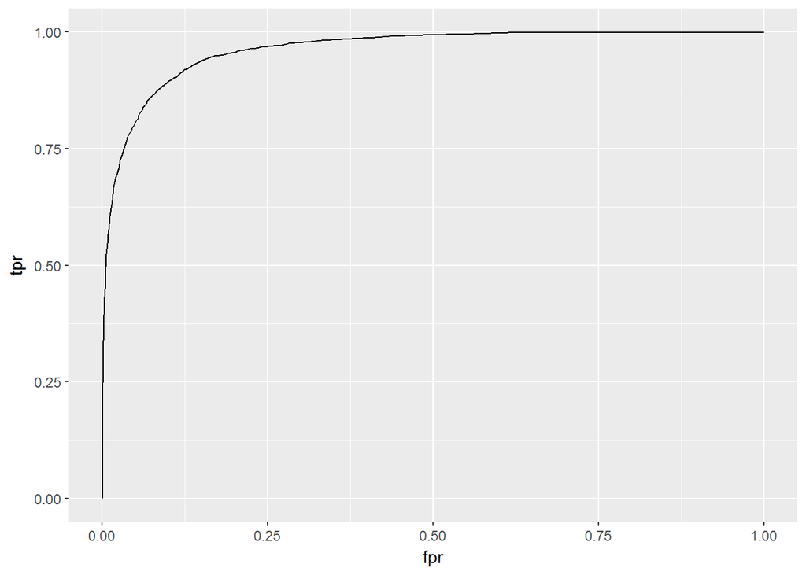

```r
rfe_roc_val = generateThreshVsPerfData(pred1, measures = list(fpr, tpr))
qplot(x = fpr, y = tpr, data = rfe_roc_val$data, geom = "path")
```

```r
performance(pred1,measures = list(mmce, acc,auc,f1))
```

```
     mmce       acc       auc        f1
0.1028245 0.8971755 0.9633135 0.8873731
```

We can infer that our model does a relatively good job to classify voters. The curve is well aligned with the true positive axis. Additionally high AUC and accuracy and the f1 score indicate our model fits the data well and has classification power

#### Gradient Boosting Decision trees

Additionally I have used gradient boosting algorithmm with a low learning rate and feature interaction to capture possible interactions between demographic characteristics and policy decisions

```r
#MlR Cross validation (I have cross-validated using a single iteration in this report, I have alreay fine tuned this model)

param = makeParamSet(
  makeDiscreteParam("n.trees", values = c(1000)),
  makeDiscreteParam("shrinkage", values = c(0.03)),
  makeDiscreteParam("interaction.depth",values=c(4)),
  makeDiscreteParam("bag.fraction",values=c(0.4)))

classif.gbm=makeLearner("classif.gbm",predict.type = "prob")

res=tuneParams(classif.gbm, task = task, resampling = rdesc,
               par.set = param, control = ctrl,measures = list(auc,f1,logloss))
```

```
Distribution not specified, assuming bernoulli ...
Distribution not specified, assuming bernoulli ...
Distribution not specified, assuming bernoulli ...
```

```r
print((as.data.frame(res$opt.path)))
```

```
  n.trees shrinkage interaction.depth bag.fraction auc.test.mean
1    1000      0.03                 4          0.4      0.964329
  f1.test.mean logloss.test.mean dob eol error.message exec.time
1    0.8898309         0.2425666   1  NA          <NA>     86.18
```

```r
classif.gbm=makeLearner("classif.gbm",predict.type = "prob"
                        ,n.trees=1000
                        ,shrinkage=0.03
                        ,interaction.depth=5
                        ,bag.fraction=0.6
)

n = getTaskSize(task)
train.set = sample(n, size = 2*n/3)
test.set = setdiff(1:n, train.set)

model = mlr::train(classif.gbm, task, subset = train.set,weights = df[train.set,1])
```

```
Distribution not specified, assuming bernoulli ...
```

```r
pred2 = predict(model, task = task,subset = test.set)
```

#### ROC Analysis of Gradient Boosting

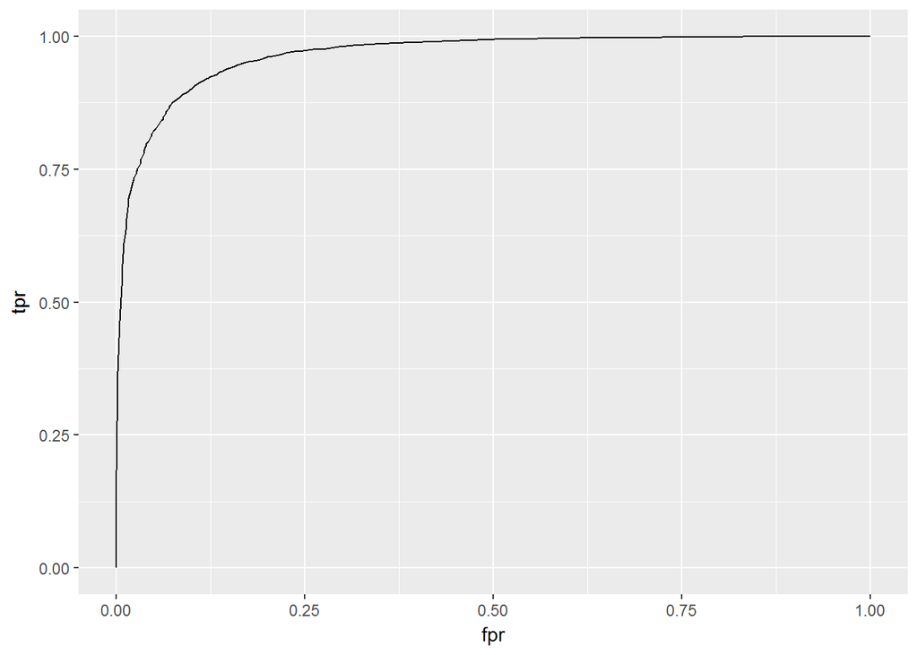

```r
gbm_roc_val = generateThreshVsPerfData(pred2, measures = list(fpr, tpr))
qplot(x = fpr, y = tpr, data = gbm_roc_val$data, geom = "path")
```

```r
performance(pred2,measures = list(mmce, acc,auc,f1))
```

```
      mmce        acc        auc         f1
0.09785751 0.90214249 0.96613065 0.89371981
```

We can infer that our model does a good job to classify voters. The curve is well aligned with the true positive axis. Additionally high AUC and accuracy and the f1 score indicate our model fits the data well and has classification power

#### Comparing the performance of the GBM model to Random Forest Model

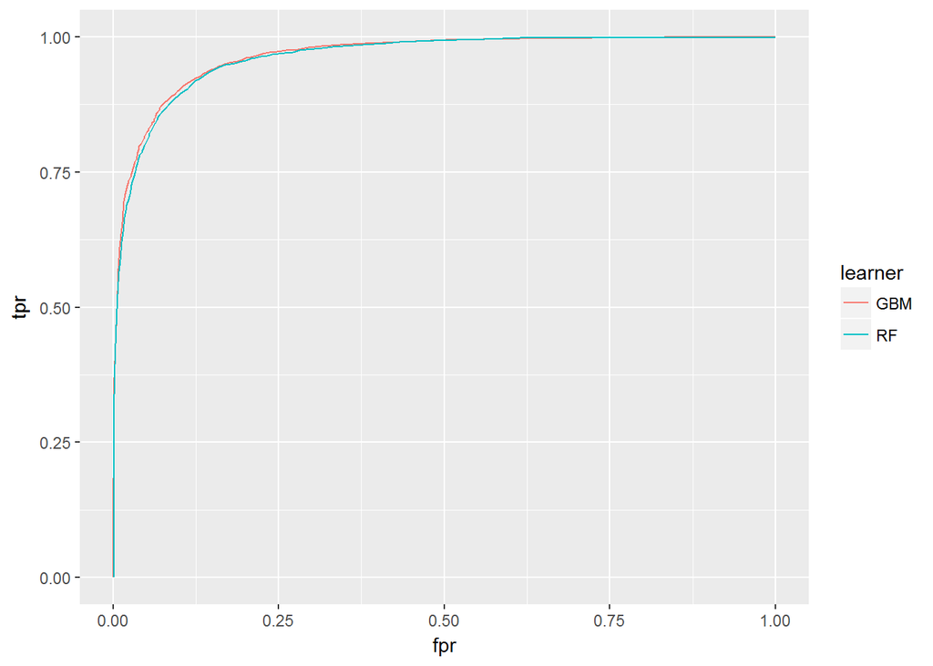

We see that the performance of the Gradient boosting model is pretty similar to the random forest model, we will use the gradient boosting model to make our predictions

#### Can we improve our performance using a stacked classifier ?

We will pass our predicted probabilities through a logistic regression classifier, logistic regression thrashes the model’s confidence in predicting class probabilities by passingit through a sigmoid function, this would ensure our model does well on rare cases which are difficult to predict

```r
#predict on original dataset

pred3=predict(model, task = task)
performance(pred3,measures = list(mmce, acc,auc,f1))
```

```
      mmce        acc        auc         f1
0.09291751 0.90708249 0.96961877 0.89817473
```

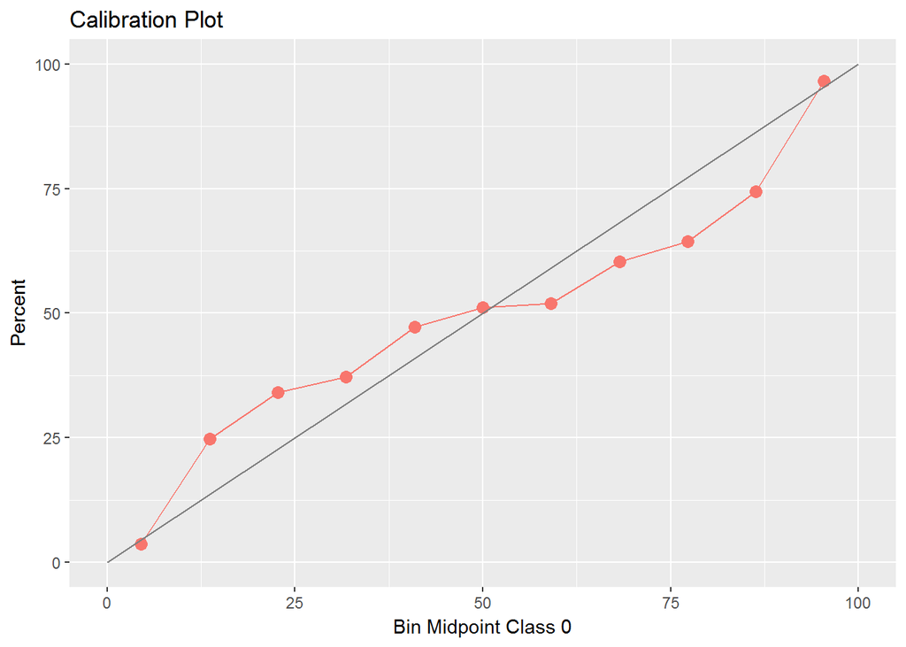

```r
df1=data.frame(id=pred3$data$id, prob=pred3$data$`prob.Hillary Clinton (Democrat)`
               ,truth=pred3$data$truth)
logitmodel= glm(truth~., data = df1[,2:3],family=binomial(link='logit'))


#let's make individual calibaration plots
logit_probs=data.frame(probs=logitmodel$fitted.values,labels=df1$truth)

#calibaration plot 0
cal_0_plot = calibration(labels ~ probs,data = logit_probs,
                         class = "Hillary Clinton (Democrat)")$data

ggplot()+xlab("Bin Midpoint Class 0")+geom_line(data = cal_0_plot, aes(midpoint, Percent), color = "#F8766D")+
geom_point(data = cal_0_plot, aes(midpoint, Percent),color = "#F8766D", size = 3) +
geom_line(aes(c(0, 100), c(0, 100)), linetype = 1, color = 'grey50')+ggtitle("Calibration Plot")
```

Let us see, if there is any improvement in the predictive ability of our model

```r
res = predict(logitmodel,newdata=df1[,2:3],type='response')
res=ifelse(res > 0.5,"Hillary Clinton (Democrat)","Donald Trump (Republican)")
confusionMatrix(res, df1$truth,mode = "everything")
```

```
Confusion Matrix and Statistics

                            Reference
Prediction                   Donald Trump (Republican)
  Donald Trump (Republican)                      16587
  Hillary Clinton (Democrat)                      1975
                            Reference
Prediction                   Hillary Clinton (Democrat)
  Donald Trump (Republican)                        1784
  Hillary Clinton (Democrat)                      20120

               Accuracy : 0.9071
                 95% CI : (0.9042, 0.9099)
    No Information Rate : 0.5413
    P-Value [Acc > NIR] : < 2.2e-16

                  Kappa : 0.8128
 Mcnemar's Test P-Value : 0.001942

            Sensitivity : 0.8936
            Specificity : 0.9186
         Pos Pred Value : 0.9029
         Neg Pred Value : 0.9106
              Precision : 0.9029
                 Recall : 0.8936
                     F1 : 0.8982
             Prevalence : 0.4587
         Detection Rate : 0.4099
   Detection Prevalence : 0.4540
      Balanced Accuracy : 0.9061

       'Positive' Class : Donald Trump (Republican)
```

Stacking does not really improve the performance of our model, finally we will predict an unseen test class, these are the individuals who voted for candidates other than Clinton and Trump, the assumtions here is that, given only 2 choices who would they have possibly voted for

```r
test=data.frame(get(load("test.RData"))[,c("commonweight","gender",
                      "edloan",
                      "race",
                      "state",
                      "economyyear",
                      "economynext",
                      "govrating",
                      "grantlegstatus",
                      "deportation",
                      "cleanair",
                      "defensecut",
                      "raisetax",
                      "medicare",
                      "guncontrol",
                      "obamacare",
                      "minwage",
                      "employmentstat")])

#impute missing values
test[,2:ncol(test)]=data.frame(sapply(test[,2:ncol(test)],
                                  function(x)(factor(x,ordered = FALSE))))

#Hot deck imputation
test=data.frame(hot.deck(test,m=2,method = "p.draw")$data[[1]])

#Test dataset, records with candidates other than Trump and Clinton
pred4 = predict(model, newdata = test)
final_test=cbind(test,pred4)

final=rbind(cbind(df[,2:18],pred3$data[,3:5]),final_test[,2:ncol(final_test)])

#file used in tableau viz challenge
save(final,file = "Prediction.Rdata")
```